# Deep Learning Lab Session

**Question 2.1.4**: Guess digit, Implement and test a python function that predict the class of a digit (the folder images_test contains some examples of images of digits)

```python
#Your implementation goes here

import os
from scipy import misc

def guess_digit(file) :
    path = '/notebooks/boughale/TP1/Images_test/'
    image= misc.imread(os.path.join(path,file), flatten= True)
    image=misc.imresize(image,(28,28))
    plt.imshow(image, cmap='gray')  # cmap='gray' is for black and white picture.
    plt.show()
    image = np.reshape(image,(784,))
    prediction = np.argmax(my_mnist_net.feedForward(image))
    print(prediction)
```

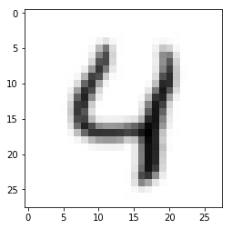

```
5
```

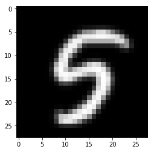

```
5
```

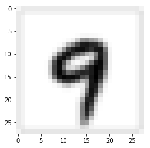

```
0
```

```python
guess_digit('4.bmp')
guess_digit('5.bmp')
guess_digit('9.bmp')
```

Our model recognized only one of the three images, so we have an accuracy of 1/3 in this case. Therefore, we have to look for better parameters in order to improve our accuracy.

**Part 2**: Change the neural network structure and parameters to optimize performance

**Question 2.2.1**: Change the learning rate (0.001, 0.1, 1.0 , 10). Train the new neural nets with the original specifications (Part 2.1), for 50 iterations. Plot test accuracy vs iteration for each learning rate on the same graph. Report the maximum test accuracy achieved for each learning rate. Which one achieves the maximum test accuracy?

```
Iteration:  1/50[==============] -Error: 0.4794807687  -Training_Accuracy:  40.18  -time: 20.05
Iteration:  2/50[==============] -Error: 0.3873083175  -Training_Accuracy:  50.43  -time: 38.01
Iteration:  3/50[==============] -Error: 0.3541212095  -Training_Accuracy:  55.71  -time: 52.15
Iteration:  4/50[==============] -Error: 0.3289571759  -Training_Accuracy:  60.04  -time: 66.25
Iteration:  5/50[==============] -Error: 0.3094321815  -Training_Accuracy:  62.15  -time: 80.38
Iteration:  6/50[==============] -Error: 0.2936425870  -Training_Accuracy:  64.31  -time: 94.55
Iteration:  7/50[==============] -Error: 0.2804217836  -Training_Accuracy:  65.89  -time: 108.98
Iteration:  8/50[==============] -Error: 0.2690830742  -Training_Accuracy:  67.52  -time: 123.12
Iteration:  9/50[==============] -Error: 0.2591689206  -Training_Accuracy:  68.71  -time: 137.27
Iteration: 10/50[==============] -Error: 0.2503589714  -Training_Accuracy:  69.80  -time: 154.37
Iteration: 11/50[==============] -Error: 0.2424424453  -Training_Accuracy:  70.93  -time: 168.62
Iteration: 12/50[==============] -Error: 0.2352146827  -Training_Accuracy:  71.85  -time: 182.84
Iteration: 13/50[==============] -Error: 0.2286245127  -Training_Accuracy:  72.63  -time: 197.02
Iteration: 14/50[==============] -Error: 0.2225096652  -Training_Accuracy:  73.45  -time: 211.23
Iteration: 15/50[==============] -Error: 0.2168317792  -Training_Accuracy:  74.24  -time: 225.80
Iteration: 16/50[==============] -Error: 0.2115616463  -Training_Accuracy:  74.95  -time: 240.00
Iteration: 17/50[==============] -Error: 0.2066113069  -Training_Accuracy:  75.57  -time: 254.20
Iteration: 18/50[==============] -Error: 0.2019834782  -Training_Accuracy:  76.15  -time: 268.41
Iteration: 19/50[==============] -Error: 0.1976672417  -Training_Accuracy:  76.67  -time: 282.60
Iteration: 20/50[==============] -Error: 0.1935751450  -Training_Accuracy:  77.13  -time: 296.80
Iteration: 21/50[==============] -Error: 0.1897387669  -Training_Accuracy:  77.60  -time: 311.02
Iteration: 22/50[==============] -Error: 0.1860864505  -Training_Accuracy:  78.07  -time: 325.20
Iteration: 23/50[==============] -Error: 0.1826678715  -Training_Accuracy:  78.42  -time: 339.41
Iteration: 24/50[==============] -Error: 0.1794153130  -Training_Accuracy:  78.85  -time: 353.85
Iteration: 25/50[==============] -Error: 0.1763327315  -Training_Accuracy:  79.28  -time: 368.06
Iteration: 26/50[==============] -Error: 0.1734100693  -Training_Accuracy:  79.56  -time: 382.30
Iteration: 27/50[==============] -Error: 0.1706287731  -Training_Accuracy:  79.91  -time: 398.04
Iteration: 28/50[==============] -Error: 0.1679960165  -Training_Accuracy:  80.19  -time: 421.20
Iteration: 29/50[==============] -Error: 0.1654682464  -Training_Accuracy:  80.49  -time: 441.07
Iteration: 30/50[==============] -Error: 0.1630672463  -Training_Accuracy:  80.76  -time: 457.01
Iteration: 31/50[==============] -Error: 0.1607646572  -Training_Accuracy:  81.08  -time: 473.79
Iteration: 32/50[==============] -Error: 0.1585636227  -Training_Accuracy:  81.31  -time: 491.16
Iteration: 33/50[==============] -Error: 0.1564564946  -Training_Accuracy:  81.58  -time: 506.42
Iteration: 34/50[==============] -Error: 0.1544271898  -Training_Accuracy:  81.85  -time: 521.58
Iteration: 35/50[==============] -Error: 0.1524834762  -Training_Accuracy:  82.03  -time: 536.36
Iteration: 36/50[==============] -Error: 0.1505974072  -Training_Accuracy:  82.25  -time: 551.49
Iteration: 37/50[==============] -Error: 0.1488077095  -Training_Accuracy:  82.49  -time: 567.67
Iteration: 38/50[==============] -Error: 0.1470628017  -Training_Accuracy:  82.64  -time: 584.95
Iteration: 39/50[==============] -Error: 0.1453860323  -Training_Accuracy:  82.86  -time: 602.32
Iteration: 40/50[==============] -Error: 0.1437719574  -Training_Accuracy:  83.08  -time: 617.06
Iteration: 41/50[==============] -Error: 0.1422110108  -Training_Accuracy:  83.25  -time: 633.87
Iteration: 42/50[==============] -Error: 0.1406961886  -Training_Accuracy:  83.39  -time: 652.23
Iteration: 43/50[==============] -Error: 0.1392389471  -Training_Accuracy:  83.60  -time: 668.42
Iteration: 44/50[==============] -Error: 0.1378344136  -Training_Accuracy:  83.78  -time: 683.07
Iteration: 45/50[==============] -Error: 0.1364719156  -Training_Accuracy:  83.97  -time: 697.50
Iteration: 46/50[==============] -Error: 0.1351550046  -Training_Accuracy:  84.11  -time: 711.81
Iteration: 47/50[==============] -Error: 0.1338843374  -Training_Accuracy:  84.30  -time: 726.00
Iteration: 48/50[==============] -Error: 0.1326493170  -Training_Accuracy:  84.44  -time: 740.33
Iteration: 49/50[==============] -Error: 0.1314500879  -Training_Accuracy:  84.59  -time: 754.50
Iteration: 50/50[==============] -Error: 0.1302918371  -Training_Accuracy:  84.73  -time: 768.72
```

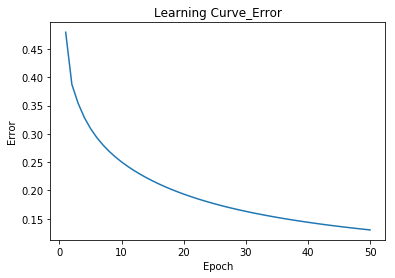

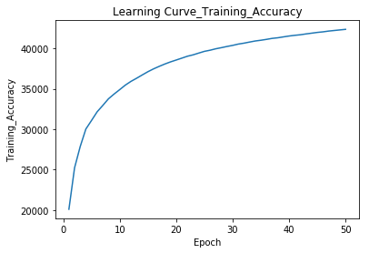

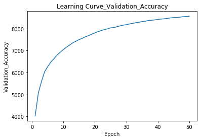

```python
#Your implementation with a learning rate of 0.001 goes here

#create the network
from NeuralNetwork import *

my_mnist_net_1 = NeuralNetwork(784,30,10,iterations=50, learning_rate = 0.001)

#train your network
my_mnist_net_1.train_with_accuracy(training_data,validation_data)
```

```python
test_accuracy=my_mnist_net_1.predict(test_data)/100
print(test_accuracy)
```

```
86.48
```

```python
my_mnist_net_1.save('Models/network_0_001')
```

```
Iteration:  1/50[==============] -Error: 0.1670630406  -Training_Accuracy:  87.40  -time: 15.55
Iteration:  2/50[==============] -Error: 0.0926027080  -Training_Accuracy:  90.32  -time: 33.85
Iteration:  3/50[==============] -Error: 0.0765151437  -Training_Accuracy:  91.56  -time: 53.17
Iteration:  4/50[==============] -Error: 0.0681073883  -Training_Accuracy:  92.48  -time: 68.75
Iteration:  5/50[==============] -Error: 0.0624685660  -Training_Accuracy:  93.19  -time: 86.97
Iteration:  6/50[==============] -Error: 0.0581499349  -Training_Accuracy:  93.66  -time: 104.17
Iteration:  7/50[==============] -Error: 0.0548282622  -Training_Accuracy:  93.76  -time: 119.62
Iteration:  8/50[==============] -Error: 0.0521112793  -Training_Accuracy:  94.13  -time: 136.48
Iteration:  9/50[==============] -Error: 0.0499858275  -Training_Accuracy:  94.34  -time: 154.61
Iteration: 10/50[==============] -Error: 0.0480933368  -Training_Accuracy:  94.69  -time: 171.24
Iteration: 11/50[==============] -Error: 0.0463578167  -Training_Accuracy:  94.95  -time: 187.09
Iteration: 12/50[==============] -Error: 0.0447601468  -Training_Accuracy:  95.00  -time: 201.76
Iteration: 13/50[==============] -Error: 0.0432679706  -Training_Accuracy:  95.21  -time: 216.26
Iteration: 14/50[==============] -Error: 0.0420776277  -Training_Accuracy:  95.26  -time: 230.79
Iteration: 15/50[==============] -Error: 0.0409822996  -Training_Accuracy:  95.48  -time: 245.42
Iteration: 16/50[==============] -Error: 0.0397301837  -Training_Accuracy:  95.50  -time: 259.94
Iteration: 17/50[==============] -Error: 0.0388929639  -Training_Accuracy:  95.64  -time: 274.44
Iteration: 18/50[==============] -Error: 0.0380107022  -Training_Accuracy:  95.77  -time: 294.81
Iteration: 19/50[==============] -Error: 0.0371798552  -Training_Accuracy:  95.76  -time: 316.27
Iteration: 20/50[==============] -Error: 0.0365089555  -Training_Accuracy:  96.00  -time: 335.79
Iteration: 21/50[==============] -Error: 0.0355586428  -Training_Accuracy:  96.08  -time: 353.87
Iteration: 22/50[==============] -Error: 0.0349352659  -Training_Accuracy:  96.03  -time: 368.87
Iteration: 23/50[==============] -Error: 0.0343021952  -Training_Accuracy:  96.19  -time: 387.56
Iteration: 24/50[==============] -Error: 0.0338186033  -Training_Accuracy:  96.24  -time: 409.34
Iteration: 25/50[==============] -Error: 0.0330770111  -Training_Accuracy:  96.34  -time: 429.73
Iteration: 26/50[==============] -Error: 0.0324386500  -Training_Accuracy:  96.37  -time: 447.11
Iteration: 27/50[==============] -Error: 0.0320729658  -Training_Accuracy:  96.50  -time: 461.99
Iteration: 28/50[==============] -Error: 0.0316008754  -Training_Accuracy:  96.41  -time: 479.81
Iteration: 29/50[==============] -Error: 0.0311097282  -Training_Accuracy:  96.54  -time: 494.48
Iteration: 30/50[==============] -Error: 0.0306582535  -Training_Accuracy:  96.55  -time: 508.72
Iteration: 31/50[==============] -Error: 0.0302916782  -Training_Accuracy:  96.60  -time: 524.32
Iteration: 32/50[==============] -Error: 0.0298977960  -Training_Accuracy:  96.65  -time: 545.60
Iteration: 33/50[==============] -Error: 0.0295294939  -Training_Accuracy:  96.63  -time: 565.03
Iteration: 34/50[==============] -Error: 0.0291817643  -Training_Accuracy:  96.75  -time: 579.26
Iteration: 35/50[==============] -Error: 0.0288535012  -Training_Accuracy:  96.78  -time: 593.55
Iteration: 36/50[==============] -Error: 0.0284218441  -Training_Accuracy:  96.76  -time: 609.00
Iteration: 37/50[==============] -Error: 0.0282103768  -Training_Accuracy:  96.85  -time: 628.62
Iteration: 38/50[==============] -Error: 0.0278817970  -Training_Accuracy:  96.84  -time: 652.41
Iteration: 39/50[==============] -Error: 0.0273734503  -Training_Accuracy:  96.92  -time: 674.60
Iteration: 40/50[==============] -Error: 0.0270655933  -Training_Accuracy:  96.93  -time: 690.14
Iteration: 41/50[==============] -Error: 0.0268434546  -Training_Accuracy:  96.92  -time: 705.21
Iteration: 42/50[==============] -Error: 0.0265494496  -Training_Accuracy:  96.95  -time: 722.27
Iteration: 43/50[==============] -Error: 0.0262523223  -Training_Accuracy:  96.97  -time: 738.19
Iteration: 44/50[==============] -Error: 0.0260215215  -Training_Accuracy:  97.01  -time: 753.41
Iteration: 45/50[==============] -Error: 0.0257731078  -Training_Accuracy:  97.06  -time: 767.69
Iteration: 46/50[==============] -Error: 0.0255269037  -Training_Accuracy:  97.03  -time: 781.99
Iteration: 47/50[==============] -Error: 0.0252272655  -Training_Accuracy:  97.08  -time: 796.27
Iteration: 48/50[==============] -Error: 0.0251014314  -Training_Accuracy:  97.06  -time: 810.58
Iteration: 49/50[==============] -Error: 0.0247967840  -Training_Accuracy:  97.04  -time: 824.85
Iteration: 50/50[==============] -Error: 0.0244748121  -Training_Accuracy:  97.11  -time: 839.17
```

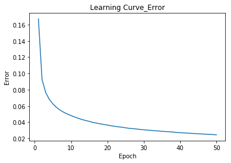

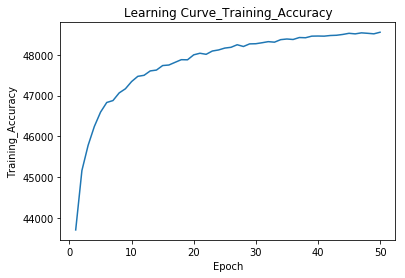

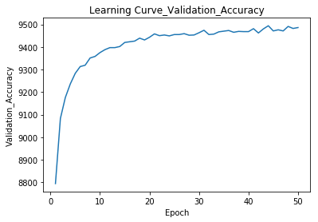

```python
#Your implementation with a learning rate of 0.1 goes here

#create the network
from NeuralNetwork import *

my_mnist_net_2 = NeuralNetwork(784,30,10,iterations=50, learning_rate = 0.1)

#train your network
my_mnist_net_2.train_with_accuracy(training_data,validation_data)
```

```python
test_accuracy=my_mnist_net_2.predict(test_data)/100
print(test_accuracy)
```

```
95.02
```

```python
my_mnist_net_2.save('Models/network_0_1')
```

```
Iteration:  1/50[==============] -Error: 0.5035304154  -Training_Accuracy:  20.65  -time: 18.32
Iteration:  2/50[==============] -Error: 0.4997256469  -Training_Accuracy:  8.80  -time: 33.63
Iteration:  3/50[==============] -Error: 0.4999998861  -Training_Accuracy:  8.79  -time: 49.29
Iteration:  4/50[==============] -Error: 0.4999998285  -Training_Accuracy:  8.78  -time: 66.93
Iteration:  5/50[==============] -Error: 0.5003765191  -Training_Accuracy:  10.85  -time: 89.90
Iteration:  6/50[==============] -Error: 0.5001372490  -Training_Accuracy:  9.03  -time: 111.16
Iteration:  7/50[==============] -Error: 0.4999996169  -Training_Accuracy:  9.02  -time: 128.81
Iteration:  8/50[==============] -Error: 0.5000040709  -Training_Accuracy:  12.68  -time: 144.73
Iteration:  9/50[==============] -Error: 0.4999998705  -Training_Accuracy:  12.85  -time: 161.82
Iteration: 10/50[==============] -Error: 0.4999998211  -Training_Accuracy:  11.27  -time: 179.01
Iteration: 11/50[==============] -Error: 0.4999996860  -Training_Accuracy:  11.85  -time: 194.01
Iteration: 12/50[==============] -Error: 0.5000257051  -Training_Accuracy:  12.00  -time: 211.51
Iteration: 13/50[==============] -Error: 0.4999997339  -Training_Accuracy:  10.46  -time: 227.49
Iteration: 14/50[==============] -Error: 0.4999999843  -Training_Accuracy:  9.92  -time: 245.23
Iteration: 15/50[==============] -Error: 0.4999998027  -Training_Accuracy:  9.79  -time: 262.63
Iteration: 16/50[==============] -Error: 0.5000024329  -Training_Accuracy:  12.03  -time: 278.89
Iteration: 17/50[==============] -Error: 0.4999999464  -Training_Accuracy:  12.01  -time: 294.64
Iteration: 18/50[==============] -Error: 0.4999999406  -Training_Accuracy:  12.00  -time: 311.55
Iteration: 19/50[==============] -Error: 0.4999999334  -Training_Accuracy:  11.98  -time: 327.46
Iteration: 20/50[==============] -Error: 0.4999999239  -Training_Accuracy:  11.91  -time: 344.23
Iteration: 21/50[==============] -Error: 0.4999999109  -Training_Accuracy:  11.89  -time: 359.31
Iteration: 22/50[==============] -Error: 0.4999998918  -Training_Accuracy:  11.90  -time: 374.00
Iteration: 23/50[==============] -Error: 0.4999998607  -Training_Accuracy:  11.96  -time: 388.89
Iteration: 24/50[==============] -Error: 0.4999997990  -Training_Accuracy:  13.80  -time: 404.75
Iteration: 25/50[==============] -Error: 0.4999995462  -Training_Accuracy:  11.80  -time: 420.58
Iteration: 26/50[==============] -Error: 0.5000902776  -Training_Accuracy:  9.04  -time: 436.05
Iteration: 27/50[==============] -Error: 0.4999989047  -Training_Accuracy:  12.00  -time: 451.02
Iteration: 28/50[==============] -Error: 0.4999999296  -Training_Accuracy:  11.44  -time: 465.98
Iteration: 29/50[==============] -Error: 0.4999999195  -Training_Accuracy:  11.48  -time: 480.52
Iteration: 30/50[==============] -Error: 0.4999999041  -Training_Accuracy:  11.46  -time: 495.06
Iteration: 31/50[==============] -Error: 0.4999998761  -Training_Accuracy:  11.32  -time: 510.41
Iteration: 32/50[==============] -Error: 0.4999997988  -Training_Accuracy:  10.82  -time: 526.42
Iteration: 33/50[==============] -Error: 0.5006240328  -Training_Accuracy:  9.02  -time: 544.67
Iteration: 34/50[==============] -Error: 0.5006612283  -Training_Accuracy:  11.53  -time: 559.56
Iteration: 35/50[==============] -Error: 0.4999999092  -Training_Accuracy:  11.59  -time: 575.41
Iteration: 36/50[==============] -Error: 0.4999998905  -Training_Accuracy:  11.68  -time: 590.15
Iteration: 37/50[==============] -Error: 0.4999998571  -Training_Accuracy:  12.01  -time: 604.54
Iteration: 38/50[==============] -Error: 0.4999997650  -Training_Accuracy:  14.73  -time: 620.92
Iteration: 39/50[==============] -Error: 0.5190398686  -Training_Accuracy:  12.47  -time: 637.21
Iteration: 40/50[==============] -Error: 0.5001519370  -Training_Accuracy:  7.94  -time: 652.46
Iteration: 41/50[==============] -Error: 0.4999998324  -Training_Accuracy:  9.94  -time: 672.70
Iteration: 42/50[==============] -Error: 0.5083101534  -Training_Accuracy:  9.94  -time: 693.15
Iteration: 43/50[==============] -Error: 0.5757966427  -Training_Accuracy:  9.91  -time: 710.22
Iteration: 44/50[==============] -Error: 0.4999999611  -Training_Accuracy:  9.88  -time: 730.80
Iteration: 45/50[==============] -Error: 0.4999999533  -Training_Accuracy:  9.80  -time: 749.12
Iteration: 46/50[==============] -Error: 0.4999999405  -Training_Accuracy:  9.78  -time: 765.90
Iteration: 47/50[==============] -Error: 0.4999999147  -Training_Accuracy:  9.76  -time: 785.83
Iteration: 48/50[==============] -Error: 0.4999998329  -Training_Accuracy:  9.73  -time: 803.47
Iteration: 49/50[==============] -Error: 0.5001350767  -Training_Accuracy:  11.53  -time: 820.69
Iteration: 50/50[==============] -Error: 0.4999999846  -Training_Accuracy:  11.52  -time: 836.91
```

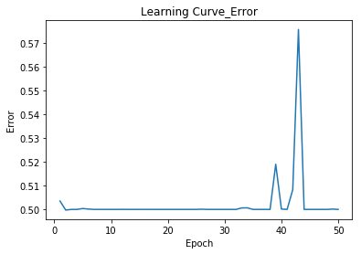

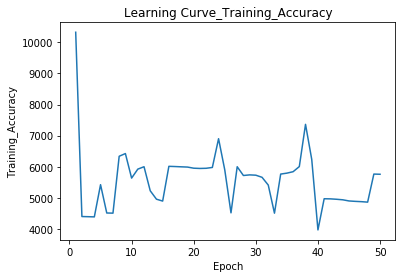

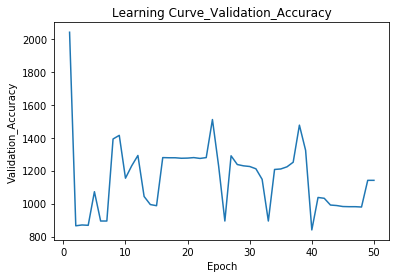

```python
#Your implementation with a learning rate of 10 goes here

#create the network
from NeuralNetwork import *

my_mnist_net_3 = NeuralNetwork(784,30,10,iterations=50, learning_rate = 10)

#train your network
my_mnist_net_3.train_with_accuracy(training_data,validation_data)
```

```python
test_accuracy=my_mnist_net_3.predict(test_data)/100
print(test_accuracy)
```

```
11.83
```

```python
my_mnist_net_3.save('Models/network_10')
```

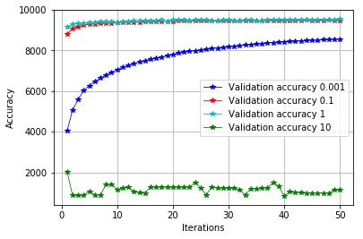

```python
plt.grid(True)
plt.plot(range(1,my_mnist_net_1.iterations+1), my_mnist_net_1.Validation_accuracies, "b", linewidth=0.8, marker="*", label="Validation accuracy 0.001")
plt.plot(range(1,my_mnist_net_2.iterations+1), my_mnist_net_2.Validation_accuracies, "r", linewidth=0.8, marker="*", label="Validation accuracy 0.1")
plt.plot(range(1,my_mnist_net.iterations+1), my_mnist_net.Validation_accuracies, "c", linewidth=0.8, marker="*", label="Validation accuracy 1")
plt.plot(range(1,my_mnist_net_3.iterations+1), my_mnist_net_3.Validation_accuracies, "g", linewidth=0.8, marker="*", label="Validation accuracy 10")
#plt.axis([80, 180, 1, 10])
plt.xlabel('Iterations')
plt.ylabel('Accuracy')
plt.legend()
plt.show()
```

```python
print('The maximum of trainig accuracy for the learning rate 0.001 is :' , max(my_mnist_net_1.Validation_accuracies))
print(' The maximum of trainig accuracy for the learning rate 0.1 is :', max(my_mnist_net_2.Validation_accuracies))
print(' The maximum of trainig accuracy for the learning rate 1 is :', max(my_mnist_net.Validation_accuracies))
print(' The maximum of trainig accuracy for the learning rate 10 is :', max(my_mnist_net_3.Validation_accuracies))
```

```
('The maximum of trainig accuracy for the learning rate 0.001 is :', 8564.0)
(' The maximum of trainig accuracy for the learning rate 0.1 is :', 9494.0)
(' The maximum of trainig accuracy for the learning rate 1 is :', 9546.0)
(' The maximum of trainig accuracy for the learning rate 10 is :', 2040.0)
```

First, when the learning rate is too low, it makes our neural network learn more slowly. Indeed, we can see that the learning curve corresponding to the error is decreasing more rapidly when the learning rate increases and the curve corresponding to the accuracy is increasing more rapidly.

For all the learning rates except 10, the error curve seems to converge to 0, so the model is learning well on training data. However, when this learning rate increases, this errors converges to 0.5. Moreover, for learning rates equal to 0.001, 0.1 and 10, the validation accuracy curve and training data accuracy curve have the same allure. So the model in these cases is not overfitting.

So the learning rate, in this case, has to be low ( between 0.1 and 1 ) in order to give good results.

**Question 2.2.2 :** initialize all weights to 0. Plot the training accuracy curve. Comment your results

```
Iteration:  1/50[==============] -Error: 0.3638786293  -Training_Accuracy:  38.93  -time: 14.30
Iteration:  2/50[==============] -Error: 0.3534040167  -Training_Accuracy:  34.28  -time: 28.58
Iteration:  3/50[==============] -Error: 0.3497161040  -Training_Accuracy:  35.09  -time: 42.84
Iteration:  4/50[==============] -Error: 0.3457942370  -Training_Accuracy:  41.15  -time: 57.09
Iteration:  5/50[==============] -Error: 0.3445371542  -Training_Accuracy:  35.96  -time: 71.34
Iteration:  6/50[==============] -Error: 0.3422982628  -Training_Accuracy:  39.60  -time: 85.62
Iteration:  7/50[==============] -Error: 0.3417616968  -Training_Accuracy:  42.60  -time: 100.07
Iteration:  8/50[==============] -Error: 0.3417425754  -Training_Accuracy:  38.91  -time: 114.40
Iteration:  9/50[==============] -Error: 0.3419739893  -Training_Accuracy:  36.25  -time: 132.94
Iteration: 10/50[==============] -Error: 0.3422719905  -Training_Accuracy:  42.53  -time: 149.45
Iteration: 11/50[==============] -Error: 0.3412598143  -Training_Accuracy:  37.48  -time: 167.87
Iteration: 12/50[==============] -Error: 0.3409853261  -Training_Accuracy:  36.78  -time: 186.28
Iteration: 13/50[==============] -Error: 0.3412914779  -Training_Accuracy:  40.32  -time: 212.22
Iteration: 14/50[==============] -Error: 0.3418408879  -Training_Accuracy:  39.96  -time: 229.96
Iteration: 15/50[==============] -Error: 0.3412686088  -Training_Accuracy:  42.55  -time: 247.94
Iteration: 16/50[==============] -Error: 0.3410724311  -Training_Accuracy:  37.34  -time: 262.83
Iteration: 17/50[==============] -Error: 0.3414062460  -Training_Accuracy:  42.89  -time: 277.33
Iteration: 18/50[==============] -Error: 0.3416388995  -Training_Accuracy:  41.71  -time: 291.83
Iteration: 19/50[==============] -Error: 0.3412307772  -Training_Accuracy:  44.50  -time: 306.51
Iteration: 20/50[==============] -Error: 0.3414744151  -Training_Accuracy:  38.55  -time: 327.25
Iteration: 21/50[==============] -Error: 0.3418477566  -Training_Accuracy:  38.67  -time: 345.11
Iteration: 22/50[==============] -Error: 0.3410647467  -Training_Accuracy:  39.25  -time: 363.66
Iteration: 23/50[==============] -Error: 0.3413324736  -Training_Accuracy:  41.25  -time: 378.72
Iteration: 24/50[==============] -Error: 0.3417322338  -Training_Accuracy:  41.34  -time: 394.83
Iteration: 25/50[==============] -Error: 0.3410558350  -Training_Accuracy:  40.93  -time: 410.61
Iteration: 26/50[==============] -Error: 0.3409830915  -Training_Accuracy:  37.18  -time: 427.18
Iteration: 27/50[==============] -Error: 0.3410967057  -Training_Accuracy:  34.91  -time: 442.16
Iteration: 28/50[==============] -Error: 0.3415917742  -Training_Accuracy:  40.45  -time: 456.95
Iteration: 29/50[==============] -Error: 0.3414868501  -Training_Accuracy:  37.37  -time: 475.68
Iteration: 30/50[==============] -Error: 0.3414634144  -Training_Accuracy:  38.74  -time: 490.86
Iteration: 31/50[==============] -Error: 0.3414921772  -Training_Accuracy:  38.33  -time: 506.08
Iteration: 32/50[==============] -Error: 0.3413046918  -Training_Accuracy:  37.46  -time: 523.32
Iteration: 33/50[==============] -Error: 0.3414711711  -Training_Accuracy:  39.71  -time: 538.07
Iteration: 34/50[==============] -Error: 0.3414578859  -Training_Accuracy:  37.39  -time: 553.60
Iteration: 35/50[==============] -Error: 0.3408562162  -Training_Accuracy:  39.08  -time: 572.88
Iteration: 36/50[==============] -Error: 0.3417824732  -Training_Accuracy:  39.49  -time: 588.86
Iteration: 37/50[==============] -Error: 0.3413676106  -Training_Accuracy:  38.81  -time: 605.25
Iteration: 38/50[==============] -Error: 0.3410879121  -Training_Accuracy:  39.95  -time: 620.19
Iteration: 39/50[==============] -Error: 0.3416807853  -Training_Accuracy:  40.85  -time: 636.15
Iteration: 40/50[==============] -Error: 0.3411822347  -Training_Accuracy:  41.33  -time: 651.18
Iteration: 41/50[==============] -Error: 0.3409741446  -Training_Accuracy:  42.19  -time: 666.51
Iteration: 42/50[==============] -Error: 0.3414050258  -Training_Accuracy:  40.85  -time: 681.83
Iteration: 43/50[==============] -Error: 0.3410785447  -Training_Accuracy:  41.29  -time: 700.05
Iteration: 44/50[==============] -Error: 0.3412423090  -Training_Accuracy:  39.19  -time: 714.88
Iteration: 45/50[==============] -Error: 0.3407680525  -Training_Accuracy:  40.65  -time: 729.69
Iteration: 46/50[==============] -Error: 0.3409104231  -Training_Accuracy:  42.04  -time: 744.50
Iteration: 47/50[==============] -Error: 0.3410036484  -Training_Accuracy:  38.70  -time: 758.98
Iteration: 48/50[==============] -Error: 0.3405780777  -Training_Accuracy:  40.14  -time: 773.54
Iteration: 49/50[==============] -Error: 0.3402002712  -Training_Accuracy:  41.33  -time: 788.15
Iteration: 50/50[==============] -Error: 0.3410460913  -Training_Accuracy:  37.07  -time: 802.73
```

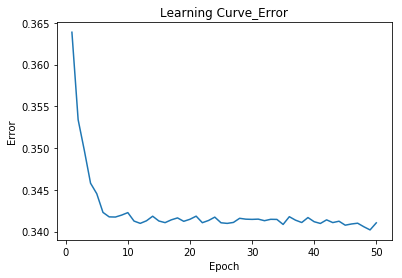

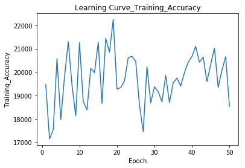

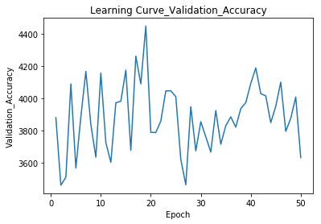

```python
#Your implementation goes here
from NeuralNetwork import *

my_mnist_net_weights_0 = NeuralNetwork(784,30,10,iterations=50, learning_rate = 1)

wo = np.zeros([31,10])
wi = np.zeros([785,30])
my_mnist_net_weights_0.weights_initialisation(wi,wo)

my_mnist_net_weights_0.train_with_accuracy(training_data,validation_data)
```

```python
test_accuracy=my_mnist_net_weights_0.predict(test_data)/100
print(test_accuracy)
```

```
36.49
```

```python
my_mnist_net_weights_0.save('Models/network_10')
```

When the weights are initialized to 0, there are two mains problems. The first one is that our model can be stuck in a local minimun.Moreover, because neurons are initialized with the same weights, they will have approximately the same gradient but also the same values and will tend to do the same thing.

**Question 2.2.3 :** Try with a different transfer function (such as tanh). File transfer_functions.py provides you the python implementation of the tanh function and its derivative

```
Iteration:  1/50[==============] -Error: 4.6811311897  -Training_Accuracy:  9.88  -time: 14.42
Iteration:  2/50[==============] -Error: 4.4999885771  -Training_Accuracy:  9.88  -time: 29.53
Iteration:  3/50[==============] -Error: 4.4999997544  -Training_Accuracy:  9.88  -time: 43.30
Iteration:  4/50[==============] -Error: 4.5706394558  -Training_Accuracy:  9.98  -time: 57.12
Iteration:  5/50[==============] -Error: 4.7069911511  -Training_Accuracy:  9.97  -time: 74.13
Iteration:  6/50[==============] -Error: 4.7827496309  -Training_Accuracy:  9.87  -time: 95.34
Iteration:  7/50[==============] -Error: 4.8872399004  -Training_Accuracy:  9.87  -time: 116.97
Iteration:  8/50[==============] -Error: 4.8872397510  -Training_Accuracy:  9.87  -time: 136.20
Iteration:  9/50[==============] -Error: 4.9970702095  -Training_Accuracy:  9.87  -time: 155.37
Iteration: 10/50[==============] -Error: 5.0815994774  -Training_Accuracy:  9.87  -time: 174.47
Iteration: 11/50[==============] -Error: 4.9135762325  -Training_Accuracy:  9.87  -time: 193.30
Iteration: 12/50[==============] -Error: 4.8872399979  -Training_Accuracy:  9.87  -time: 210.42
Iteration: 13/50[==============] -Error: 4.8872399979  -Training_Accuracy:  9.87  -time: 224.18
Iteration: 14/50[==============] -Error: 4.8872399979  -Training_Accuracy:  9.87  -time: 237.82
Iteration: 15/50[==============] -Error: 4.8872399979  -Training_Accuracy:  9.87  -time: 251.65
Iteration: 16/50[==============] -Error: 4.8872399978  -Training_Accuracy:  9.87  -time: 265.71
Iteration: 17/50[==============] -Error: 4.8872399978  -Training_Accuracy:  9.87  -time: 279.33
Iteration: 18/50[==============] -Error: 4.8872399978  -Training_Accuracy:  9.87  -time: 293.17
Iteration: 19/50[==============] -Error: 4.8872399978  -Training_Accuracy:  9.87  -time: 306.98
Iteration: 20/50[==============] -Error: 4.8872399978  -Training_Accuracy:  9.87  -time: 321.44
Iteration: 21/50[==============] -Error: 4.8872399977  -Training_Accuracy:  9.87  -time: 337.19
Iteration: 22/50[==============] -Error: 4.8872399977  -Training_Accuracy:  9.87  -time: 353.83
Iteration: 23/50[==============] -Error: 4.8872399977  -Training_Accuracy:  9.87  -time: 370.63
Iteration: 24/50[==============] -Error: 4.8872399977  -Training_Accuracy:  9.87  -time: 387.41
Iteration: 25/50[==============] -Error: 4.8872399976  -Training_Accuracy:  9.87  -time: 402.78
Iteration: 26/50[==============] -Error: 4.8872399976  -Training_Accuracy:  9.87  -time: 416.95
Iteration: 27/50[==============] -Error: 4.8872399976  -Training_Accuracy:  9.87  -time: 433.92
Iteration: 28/50[==============] -Error: 4.8872399976  -Training_Accuracy:  9.87  -time: 449.47
Iteration: 29/50[==============] -Error: 4.8872399976  -Training_Accuracy:  9.87  -time: 464.66
Iteration: 30/50[==============] -Error: 4.8872399975  -Training_Accuracy:  9.87  -time: 483.01
Iteration: 31/50[==============] -Error: 4.8872399975  -Training_Accuracy:  9.87  -time: 498.91
Iteration: 32/50[==============] -Error: 4.8872399975  -Training_Accuracy:  9.87  -time: 514.45
Iteration: 33/50[==============] -Error: 4.8872399974  -Training_Accuracy:  9.87  -time: 530.08
Iteration: 34/50[==============] -Error: 4.8872399974  -Training_Accuracy:  9.87  -time: 545.15
Iteration: 35/50[==============] -Error: 4.8872399974  -Training_Accuracy:  9.87  -time: 559.49
Iteration: 36/50[==============] -Error: 4.8872399974  -Training_Accuracy:  9.87  -time: 574.00
Iteration: 37/50[==============] -Error: 4.8872399973  -Training_Accuracy:  9.87  -time: 588.24
Iteration: 38/50[==============] -Error: 4.8872399973  -Training_Accuracy:  9.87  -time: 603.73
Iteration: 39/50[==============] -Error: 4.8872399973  -Training_Accuracy:  9.87  -time: 618.07
Iteration: 40/50[==============] -Error: 4.8872399972  -Training_Accuracy:  9.87  -time: 638.45
Iteration: 41/50[==============] -Error: 4.8872399972  -Training_Accuracy:  9.87  -time: 654.58
Iteration: 42/50[==============] -Error: 4.8872399972  -Training_Accuracy:  9.87  -time: 668.94
Iteration: 43/50[==============] -Error: 4.8872399971  -Training_Accuracy:  9.87  -time: 684.19
Iteration: 44/50[==============] -Error: 4.8872399971  -Training_Accuracy:  9.87  -time: 698.25
Iteration: 45/50[==============] -Error: 4.8872399971  -Training_Accuracy:  9.87  -time: 712.21
Iteration: 46/50[==============] -Error: 4.8872399970  -Training_Accuracy:  9.87  -time: 729.56
Iteration: 47/50[==============] -Error: 4.8872399970  -Training_Accuracy:  9.87  -time: 744.71
Iteration: 48/50[==============] -Error: 4.8872399970  -Training_Accuracy:  9.87  -time: 758.53
Iteration: 49/50[==============] -Error: 4.8872399969  -Training_Accuracy:  9.87  -time: 772.50
Iteration: 50/50[==============] -Error: 4.8872399969  -Training_Accuracy:  9.87  -time: 786.52
```

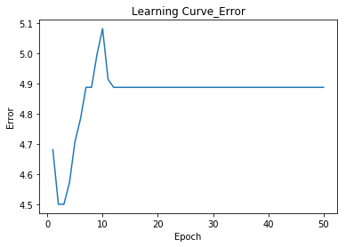

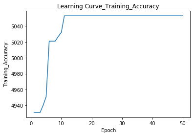

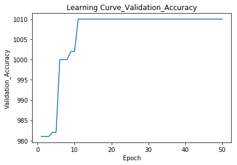

```python
#Your implementation goes here

from NeuralNetwork import *

my_mnist_net = NeuralNetwork(784,30,10,iterations=50, learning_rate = 1)


my_mnist_net.train_with_accuracy_tanh(training_data,validation_data)
```

```python
my_mnist_net.save('Models/network_tanh')
```

```
Iteration:  1/50[==============] -Error: 1.2731809493  -Training_Accuracy:  19.48  -time: 13.81
Iteration:  2/50[==============] -Error: 1.0436478908  -Training_Accuracy:  43.09  -time: 27.59
Iteration:  3/50[==============] -Error: 0.9934077204  -Training_Accuracy:  42.83  -time: 41.20
Iteration:  4/50[==============] -Error: 0.9610170791  -Training_Accuracy:  44.48  -time: 55.79
Iteration:  5/50[==============] -Error: 0.9463237553  -Training_Accuracy:  36.45  -time: 75.62
Iteration:  6/50[==============] -Error: 0.9385545646  -Training_Accuracy:  32.30  -time: 89.29
Iteration:  7/50[==============] -Error: 0.9310464732  -Training_Accuracy:  18.51  -time: 103.16
Iteration:  8/50[==============] -Error: 0.9203799375  -Training_Accuracy:  52.85  -time: 117.04
Iteration:  9/50[==============] -Error: 0.9186581265  -Training_Accuracy:  39.11  -time: 132.54
Iteration: 10/50[==============] -Error: 0.9111232923  -Training_Accuracy:  34.78  -time: 150.44
Iteration: 11/50[==============] -Error: 0.9118510522  -Training_Accuracy:  34.09  -time: 164.32
Iteration: 12/50[==============] -Error: 0.9006003657  -Training_Accuracy:  49.08  -time: 178.37
Iteration: 13/50[==============] -Error: 0.9048857199  -Training_Accuracy:  38.33  -time: 192.41
Iteration: 14/50[==============] -Error: 0.8932710018  -Training_Accuracy:  55.93  -time: 208.13
Iteration: 15/50[==============] -Error: 0.8979264857  -Training_Accuracy:  38.24  -time: 225.20
Iteration: 16/50[==============] -Error: 0.8891213301  -Training_Accuracy:  43.57  -time: 240.03
Iteration: 17/50[==============] -Error: 0.8840431137  -Training_Accuracy:  43.80  -time: 254.65
Iteration: 18/50[==============] -Error: 0.8884693272  -Training_Accuracy:  35.02  -time: 270.63
Iteration: 19/50[==============] -Error: 0.8851710555  -Training_Accuracy:  27.77  -time: 284.81
Iteration: 20/50[==============] -Error: 0.8768648078  -Training_Accuracy:  38.62  -time: 299.18
Iteration: 21/50[==============] -Error: 0.8771228750  -Training_Accuracy:  57.09  -time: 313.38
Iteration: 22/50[==============] -Error: 0.8780902554  -Training_Accuracy:  52.96  -time: 332.68
Iteration: 23/50[==============] -Error: 0.8744529615  -Training_Accuracy:  66.08  -time: 346.70
Iteration: 24/50[==============] -Error: 0.8658819381  -Training_Accuracy:  43.91  -time: 360.51
Iteration: 25/50[==============] -Error: 0.8715715544  -Training_Accuracy:  42.09  -time: 374.54
Iteration: 26/50[==============] -Error: 0.8747341937  -Training_Accuracy:  44.65  -time: 388.59
Iteration: 27/50[==============] -Error: 0.8727570377  -Training_Accuracy:  42.60  -time: 402.51
Iteration: 28/50[==============] -Error: 0.8618367125  -Training_Accuracy:  38.44  -time: 416.88
Iteration: 29/50[==============] -Error: 0.8633846306  -Training_Accuracy:  36.34  -time: 430.80
Iteration: 30/50[==============] -Error: 0.8593659941  -Training_Accuracy:  47.45  -time: 444.53
Iteration: 31/50[==============] -Error: 0.8549412774  -Training_Accuracy:  47.47  -time: 458.45
Iteration: 32/50[==============] -Error: 0.8584183661  -Training_Accuracy:  33.14  -time: 473.43
Iteration: 33/50[==============] -Error: 0.8584892535  -Training_Accuracy:  44.32  -time: 487.29
Iteration: 34/50[==============] -Error: 0.8555147173  -Training_Accuracy:  46.63  -time: 501.34
Iteration: 35/50[==============] -Error: 0.8512323526  -Training_Accuracy:  37.92  -time: 515.40
Iteration: 36/50[==============] -Error: 0.8490061923  -Training_Accuracy:  31.55  -time: 534.60
Iteration: 37/50[==============] -Error: 0.8460069900  -Training_Accuracy:  42.02  -time: 550.21
Iteration: 38/50[==============] -Error: 0.8513549971  -Training_Accuracy:  47.20  -time: 564.93
Iteration: 39/50[==============] -Error: 0.8458667906  -Training_Accuracy:  40.87  -time: 579.03
Iteration: 40/50[==============] -Error: 0.8498445714  -Training_Accuracy:  33.82  -time: 594.31
Iteration: 41/50[==============] -Error: 0.8557124754  -Training_Accuracy:  24.45  -time: 613.71
Iteration: 42/50[==============] -Error: 0.8559893869  -Training_Accuracy:  32.33  -time: 632.89
Iteration: 43/50[==============] -Error: 0.8590696352  -Training_Accuracy:  39.10  -time: 646.86
Iteration: 44/50[==============] -Error: 0.8495656633  -Training_Accuracy:  40.33  -time: 661.04
Iteration: 45/50[==============] -Error: 0.8517468930  -Training_Accuracy:  42.30  -time: 674.75
Iteration: 46/50[==============] -Error: 0.8427252906  -Training_Accuracy:  41.74  -time: 688.63
Iteration: 47/50[==============] -Error: 0.8473088984  -Training_Accuracy:  38.74  -time: 702.54
Iteration: 48/50[==============] -Error: 0.8499791538  -Training_Accuracy:  32.44  -time: 717.94
Iteration: 49/50[==============] -Error: 0.8414382010  -Training_Accuracy:  44.50  -time: 731.81
Iteration: 50/50[==============] -Error: 0.8461054559  -Training_Accuracy:  52.24  -time: 750.58
```

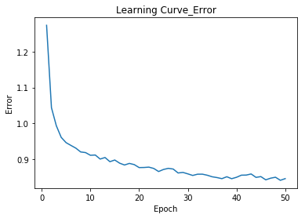

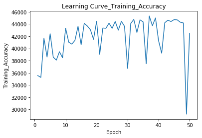

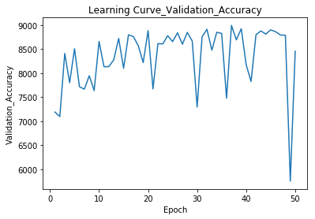

```python
#Your implementation goes here

from NeuralNetwork import *

my_mnist_net_tanh_01 = NeuralNetwork(784,30,10,iterations=50, learning_rate = 0.1)


my_mnist_net_tanh_01.train_with_accuracy_tanh(training_data,validation_data)
```

```python
my_mnist_net_tanh_01.save('Models/network_tanh01')
```

First, the difference between the tanh function and sigmoid is that the range of tanh is [-1,1] and of the sigmoid is [0,1].

The use of sigmoid function seems to give better results than tanh function. Indeed, with tanh function, we can see that the training accuracy converges rapidly to 5050 (10% ) whereas it converges to 48500 ( 97 % ) for the sigmoid function. Howeover, when we change the learning rate from 1 to 0.1, we remark that we obtain better results ( learning rate 0.1 better than 1 for tanh function). Indeed, the accuracy is equal in average to 80 %, the same thing for the accuracy on validation data.

**Question 2.2.4 :** Add more neurons in the hidden layer (try with 100, 200, 300). Plot the curve representing the validation accuracy versus the number of neurons in the hidden layer. (Choose and justify other hyper-parameters)

```
Iteration:  1/50[==============] -Error: 0.1160283249  -Training_Accuracy:  91.68  -time: 24.06
Iteration:  2/50[==============] -Error: 0.0731634989  -Training_Accuracy:  93.06  -time: 49.11
Iteration:  3/50[==============] -Error: 0.0622243373  -Training_Accuracy:  94.19  -time: 73.55
Iteration:  4/50[==============] -Error: 0.0584553759  -Training_Accuracy:  94.16  -time: 96.34
Iteration:  5/50[==============] -Error: 0.0566169162  -Training_Accuracy:  94.93  -time: 123.99
Iteration:  6/50[==============] -Error: 0.0518472131  -Training_Accuracy:  94.86  -time: 146.83
Iteration:  7/50[==============] -Error: 0.0472830566  -Training_Accuracy:  95.15  -time: 169.80
Iteration:  8/50[==============] -Error: 0.0481290725  -Training_Accuracy:  95.51  -time: 193.02
Iteration:  9/50[==============] -Error: 0.0456473206  -Training_Accuracy:  95.43  -time: 215.64
Iteration: 10/50[==============] -Error: 0.0448091604  -Training_Accuracy:  95.75  -time: 238.47
Iteration: 11/50[==============] -Error: 0.0423479259  -Training_Accuracy:  96.11  -time: 261.23
Iteration: 12/50[==============] -Error: 0.0425510123  -Training_Accuracy:  96.04  -time: 284.05
Iteration: 13/50[==============] -Error: 0.0413719081  -Training_Accuracy:  96.20  -time: 307.26
Iteration: 14/50[==============] -Error: 0.0388234371  -Training_Accuracy:  96.42  -time: 329.92
Iteration: 15/50[==============] -Error: 0.0392603097  -Training_Accuracy:  96.17  -time: 352.74
Iteration: 16/50[==============] -Error: 0.0389938452  -Training_Accuracy:  96.67  -time: 375.63
Iteration: 17/50[==============] -Error: 0.0365102561  -Training_Accuracy:  96.50  -time: 398.43
Iteration: 18/50[==============] -Error: 0.0378114313  -Training_Accuracy:  96.09  -time: 421.40
Iteration: 19/50[==============] -Error: 0.0375290121  -Training_Accuracy:  96.27  -time: 444.40
Iteration: 20/50[==============] -Error: 0.0369473389  -Training_Accuracy:  96.59  -time: 471.23
Iteration: 21/50[==============] -Error: 0.0361057508  -Training_Accuracy:  96.21  -time: 499.16
Iteration: 22/50[==============] -Error: 0.0363448757  -Training_Accuracy:  96.53  -time: 522.66
Iteration: 23/50[==============] -Error: 0.0351757631  -Training_Accuracy:  96.15  -time: 550.97
Iteration: 24/50[==============] -Error: 0.0366311377  -Training_Accuracy:  96.27  -time: 582.37
Iteration: 25/50[==============] -Error: 0.0359911538  -Training_Accuracy:  96.84  -time: 612.18
Iteration: 26/50[==============] -Error: 0.0354937841  -Training_Accuracy:  96.48  -time: 643.47
Iteration: 27/50[==============] -Error: 0.0374460814  -Training_Accuracy:  96.79  -time: 670.35
Iteration: 28/50[==============] -Error: 0.0338712118  -Training_Accuracy:  96.93  -time: 695.10
Iteration: 29/50[==============] -Error: 0.0336732507  -Training_Accuracy:  96.97  -time: 722.83
Iteration: 30/50[==============] -Error: 0.0343742135  -Training_Accuracy:  96.62  -time: 748.99
Iteration: 31/50[==============] -Error: 0.0337585497  -Training_Accuracy:  96.89  -time: 775.25
Iteration: 32/50[==============] -Error: 0.0334169674  -Training_Accuracy:  96.80  -time: 801.40
Iteration: 33/50[==============] -Error: 0.0322011057  -Training_Accuracy:  96.97  -time: 826.19
Iteration: 34/50[==============] -Error: 0.0312474565  -Training_Accuracy:  97.05  -time: 850.60
Iteration: 35/50[==============] -Error: 0.0330098023  -Training_Accuracy:  96.82  -time: 876.45
Iteration: 36/50[==============] -Error: 0.0328353915  -Training_Accuracy:  96.93  -time: 903.79
Iteration: 37/50[==============] -Error: 0.0307630401  -Training_Accuracy:  96.92  -time: 927.90
Iteration: 38/50[==============] -Error: 0.0298381828  -Training_Accuracy:  97.16  -time: 952.40
Iteration: 39/50[==============] -Error: 0.0302076080  -Training_Accuracy:  97.13  -time: 978.08
Iteration: 40/50[==============] -Error: 0.0300522637  -Training_Accuracy:  97.21  -time: 1003.39
Iteration: 41/50[==============] -Error: 0.0295993265  -Training_Accuracy:  97.19  -time: 1035.34
Iteration: 42/50[==============] -Error: 0.0284603390  -Training_Accuracy:  97.44  -time: 1061.04
Iteration: 43/50[==============] -Error: 0.0284694923  -Training_Accuracy:  97.26  -time: 1088.67
Iteration: 44/50[==============] -Error: 0.0279286768  -Training_Accuracy:  97.55  -time: 1114.49
Iteration: 45/50[==============] -Error: 0.0300273662  -Training_Accuracy:  97.21  -time: 1137.71
Iteration: 46/50[==============] -Error: 0.0305184244  -Training_Accuracy:  97.03  -time: 1161.09
Iteration: 47/50[==============] -Error: 0.0319089773  -Training_Accuracy:  97.13  -time: 1194.33
Iteration: 48/50[==============] -Error: 0.0307367299  -Training_Accuracy:  97.14  -time: 1221.68
Iteration: 49/50[==============] -Error: 0.0288815296  -Training_Accuracy:  97.20  -time: 1247.01
Iteration: 50/50[==============] -Error: 0.0298763808  -Training_Accuracy:  97.48  -time: 1274.19
```

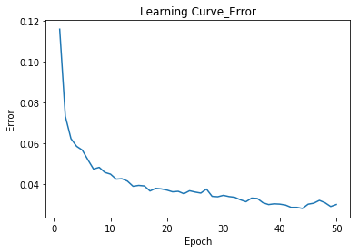

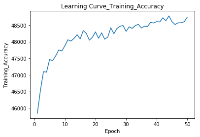

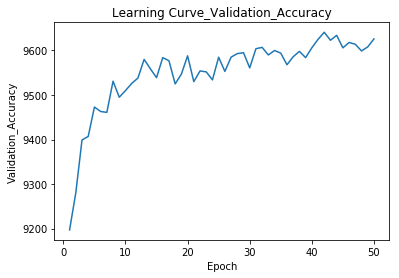

```python
#Your implementation goes here


from NeuralNetwork import *

my_mnist_net = NeuralNetwork(784,100,10,iterations=50, learning_rate = 1)


my_mnist_net.train_with_accuracy(training_data,validation_data)
```

```python
test_accuracy=my_mnist_net.predict(test_data)/100
print(test_accuracy)
```

```
96.77
```

```python
my_mnist_net.save('Models/network_100')
```

```
Iteration:  1/50[==============] -Error: 0.1262924652  -Training_Accuracy:  91.08  -time: 44.98
Iteration:  2/50[==============] -Error: 0.0754606483  -Training_Accuracy:  93.79  -time: 84.51
Iteration:  3/50[==============] -Error: 0.0631794211  -Training_Accuracy:  94.48  -time: 131.34
Iteration:  4/50[==============] -Error: 0.0570404709  -Training_Accuracy:  94.28  -time: 172.86
Iteration:  5/50[==============] -Error: 0.0550018523  -Training_Accuracy:  95.28  -time: 213.37
Iteration:  6/50[==============] -Error: 0.0529857065  -Training_Accuracy:  95.19  -time: 250.67
Iteration:  7/50[==============] -Error: 0.0494222201  -Training_Accuracy:  95.69  -time: 288.12
Iteration:  8/50[==============] -Error: 0.0471546564  -Training_Accuracy:  95.91  -time: 324.44
Iteration:  9/50[==============] -Error: 0.0441598048  -Training_Accuracy:  96.06  -time: 366.81
Iteration: 10/50[==============] -Error: 0.0439387250  -Training_Accuracy:  95.97  -time: 409.86
Iteration: 11/50[==============] -Error: 0.0440742267  -Training_Accuracy:  95.22  -time: 448.00
Iteration: 12/50[==============] -Error: 0.0421594790  -Training_Accuracy:  96.10  -time: 485.91
Iteration: 13/50[==============] -Error: 0.0403371286  -Training_Accuracy:  96.46  -time: 529.41
Iteration: 14/50[==============] -Error: 0.0415217129  -Training_Accuracy:  96.17  -time: 573.52
Iteration: 15/50[==============] -Error: 0.0393030929  -Training_Accuracy:  96.11  -time: 614.86
Iteration: 16/50[==============] -Error: 0.0389168187  -Training_Accuracy:  96.59  -time: 654.25
Iteration: 17/50[==============] -Error: 0.0374882987  -Training_Accuracy:  96.82  -time: 698.16
Iteration: 18/50[==============] -Error: 0.0376788126  -Training_Accuracy:  96.80  -time: 741.76
Iteration: 19/50[==============] -Error: 0.0379757116  -Training_Accuracy:  96.60  -time: 778.11
Iteration: 20/50[==============] -Error: 0.0362459877  -Training_Accuracy:  96.91  -time: 814.08
Iteration: 21/50[==============] -Error: 0.0346863970  -Training_Accuracy:  96.49  -time: 850.17
Iteration: 22/50[==============] -Error: 0.0362935397  -Training_Accuracy:  96.69  -time: 886.30
Iteration: 23/50[==============] -Error: 0.0356895838  -Training_Accuracy:  96.84  -time: 922.47
Iteration: 24/50[==============] -Error: 0.0366975997  -Training_Accuracy:  96.65  -time: 958.58
Iteration: 25/50[==============] -Error: 0.0368863120  -Training_Accuracy:  96.80  -time: 994.42
Iteration: 26/50[==============] -Error: 0.0337584256  -Training_Accuracy:  97.07  -time: 1030.91
Iteration: 27/50[==============] -Error: 0.0347427996  -Training_Accuracy:  97.01  -time: 1066.87
Iteration: 28/50[==============] -Error: 0.0362280739  -Training_Accuracy:  96.68  -time: 1102.37
Iteration: 29/50[==============] -Error: 0.0344363889  -Training_Accuracy:  97.09  -time: 1138.27
Iteration: 30/50[==============] -Error: 0.0343466002  -Training_Accuracy:  97.08  -time: 1173.89
Iteration: 31/50[==============] -Error: 0.0332039066  -Training_Accuracy:  97.04  -time: 1209.39
Iteration: 32/50[==============] -Error: 0.0335421807  -Training_Accuracy:  97.32  -time: 1245.46
Iteration: 33/50[==============] -Error: 0.0300891034  -Training_Accuracy:  97.04  -time: 1281.60
Iteration: 34/50[==============] -Error: 0.0309245211  -Training_Accuracy:  97.31  -time: 1317.59
Iteration: 35/50[==============] -Error: 0.0304773905  -Training_Accuracy:  97.22  -time: 1353.81
Iteration: 36/50[==============] -Error: 0.0299289030  -Training_Accuracy:  97.47  -time: 1390.33
Iteration: 37/50[==============] -Error: 0.0312385292  -Training_Accuracy:  97.45  -time: 1426.20
Iteration: 38/50[==============] -Error: 0.0295308176  -Training_Accuracy:  97.47  -time: 1461.96
Iteration: 39/50[==============] -Error: 0.0310365518  -Training_Accuracy:  97.49  -time: 1498.40
Iteration: 40/50[==============] -Error: 0.0289467798  -Training_Accuracy:  97.44  -time: 1534.68
Iteration: 41/50[==============] -Error: 0.0296214517  -Training_Accuracy:  97.14  -time: 1571.30
Iteration: 42/50[==============] -Error: 0.0317271644  -Training_Accuracy:  97.26  -time: 1608.28
Iteration: 43/50[==============] -Error: 0.0306886329  -Training_Accuracy:  96.95  -time: 1644.79
Iteration: 44/50[==============] -Error: 0.0299053983  -Training_Accuracy:  97.48  -time: 1681.13
Iteration: 45/50[==============] -Error: 0.0312117165  -Training_Accuracy:  97.32  -time: 1717.48
Iteration: 46/50[==============] -Error: 0.0300935846  -Training_Accuracy:  97.16  -time: 1754.37
Iteration: 47/50[==============] -Error: 0.0303089047  -Training_Accuracy:  97.37  -time: 1791.20
Iteration: 48/50[==============] -Error: 0.0297849646  -Training_Accuracy:  97.56  -time: 1827.44
Iteration: 49/50[==============] -Error: 0.0299035483  -Training_Accuracy:  97.56  -time: 1868.50
Iteration: 50/50[==============] -Error: 0.0304974136  -Training_Accuracy:  97.15  -time: 1908.21
```

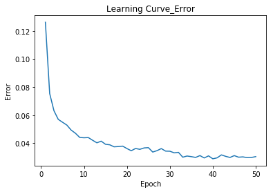

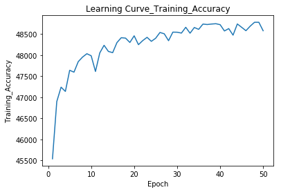

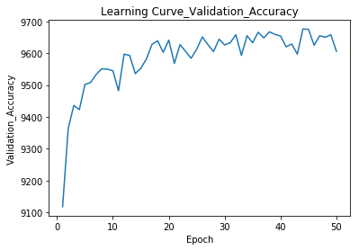

```python
from NeuralNetwork import *

my_mnist_net_2 = NeuralNetwork(784,200,10,iterations=50, learning_rate = 1)


my_mnist_net_2.train_with_accuracy(training_data,validation_data)
```